# GS in CIMMYT Wheat

Make this your own

July 22, 2018

# Objective

Set up a genomic selection for CIMMYT wheat trials. The data included are a hapmap file that has previously been imputed using Beagle. The phenotype data file consist of 3 site years of data, 14_OBR_EYT–2014 Drought, 15_OBR_EYT – 2015 Drought, 14_OBR_EYTHeat – 2015 heat. Note that not all phenotypes were included each year. The lines were grouped into trials, with trials composing sister (highly related lines).

The phenotype information includes:  
GID_DNA: This is the individual unique number that links to the hapmap file blup_gs1: Model estimated value for NDVI 1st measurement  
blup_gs2: Model estimated value for NDVI 2nd measurement blup_gs3: Model estimated value for NDVI 3rd measurement  
blup_n1: Model estimated value for canopy temperature 1st measurement blup_n2: Model estimated value for canopy temperature 2nd measurement blup_n3: Model estimated value for canopy temperature 3rd measurement Experiment_id: Identifies year and type of experiment heat or drought  
Entry: Entry number  
cimmyt_tid: CIMMYT Trial ID, grouping of individuals into trial  
notes: notes  
gy_effect: Estimated BLUP (0 centered) of grain yield  
gs: average of blup_gs1, blup_gs2, blup_gs3, and blup_gs4  
ir: average of blup_n1, blup_n2, blup_n3, blup_n4  
model: information about the model used to calcuate trial BLUPs blup_gs4: Model estimated value for NDVI 4th measurement blup_n4: Model estimated value for canopy temperature 4th measurement

This data is from Crain et al. (2018), Combining High-Throughput Phenotyping and Genomic Information to Increase Prediction and Selection Accuracy in Wheat Breeding. The data sets and scripts are stored at https://datadryad.org/resource/doi:10.5061/dryad.7f138.

# Objective 1: Set up a model using only the drought 2014 data for grain yield.

```r
knitr::opts_knit$set(root.dir = '/Users/jcrain/Documents/Class/Genomic_Selection/Github/BecA/Trial_Data/')
setwd('/Users/jcrain/Documents/Class/Genomic_Selection/Github/BecA/Trial_Data/')
options(digits = 10) #set options to include lots of digits
#Git link
#https://github.com/jcrain1/BecA
```

```r
####Function to count alleles and populations parameters###
tassel5_to_params=function(x="hap matrix", y="columns to skip", z="population number"){
      geno=x
      #recount allele A and B and het
      alleleA=rowSums(geno[,(y+1):ncol(geno)]!=substring(geno$alleles, 3, 3) & geno[,(y+1):ncol(geno)]!="N") #only counts what is not allele B and missing.  i.e. counts allele A and various calls for heterozygous
      alleleB=rowSums(geno[,(y+1):ncol(geno)]!=substring(geno$alleles, 1, 1) & geno[,(y+1):ncol(geno)]!="N")
      het=rowSums(geno[,(y+1):ncol(geno)] == "M") + rowSums( geno[,(y+1):ncol(geno)] ==   "R") + rowSums(geno[,(y+1):ncol(geno)] ==  "W") + rowSums(geno[,(y+1):ncol(geno)] ==  "K") + rowSums(geno[,(y+1):ncol(geno)] ==  "S") + rowSums(geno[,(y+1):ncol(geno)] ==  "Y")
      present=1-(rowSums(geno[,(y+1):ncol(geno)]=="N")/z)
      MAF=apply(cbind(((alleleA-het)*2+het), (alleleB-het)*2+het), 1, min)/apply(
    cbind(((alleleA-het)*2+het), ((alleleB-het)*2+het)), 1, sum)
      percentHet=het/apply(cbind(alleleA-het, alleleB-het, het), 1, sum)
      return(cbind.data.frame(geno[,1:y], "alleleA"=alleleA, "alleleB"=alleleB, "het"=het, "present"= present, "MAF"=MAF, "percentHET"=percentHet, geno[,(y+1):ncol(geno)]))
}

##function to convert hap to 0 and 1
hap_to_G=function(x="hap matrix", y="number of columns of information"){
  ##From Prasana, pulls out first allele for a and second for b
  a = substring(x$alleles,1,1)
  #Checks the frequency of the alleles if the second allele is more frequent it is substitued
  a[x$alleleA<x$alleleB] = substring(x$alleles,3,3)[x$alleleA<x$alleleB]
  #Same thing with the second allele
  b = substring(x$alleles,3,3)
  b[x$alleleA<x$alleleB] = substring(x$alleles,1,1)[x$alleleA<x$alleleB]
  #Checks to make sure all alleles are one or the other
  #print(paste("If 0 all alleles are accounted for: ", sum(a == b), sep=""))

  ## Turn into letter matrix for mapping
  #makes a copy of the hap matrix
  hap01 = x
  #sets all allele values to NA
  hap01[,(y+1):ncol(hap01)]=NA

  ## Turn allele a and allele b into 1 and -1.  Het into 0
  #line by line if a line is a then it places 1 in hap01 for the allele
  hap01[x == a] = 1
  hap01[x == b] = -1
  hap01[x == "M"] = 0
  hap01[x == "Y"] = 0
  hap01[x == "K"] = 0
  hap01[x == "R"] = 0
  hap01[x == "W"] = 0
  hap01[x == "S"] = 0
  hap01[x== "N"]=NA

  return(hap01)}
```

# Load Data

```r
marker <- read.delim(file = './data/Original_Data/Beagle_Imputed.hmp.txt', check.names = FALSE, header = TRUE, stringsAsFactors = FALSE) #load marker data

phen <- read.table(file = './data/Original_Data/EYT_Phenotype_Imputed_GS_Simple.txt', header = TRUE, stringsAsFactors = FALSE) #load phenoytpe data
```

# Examine Data

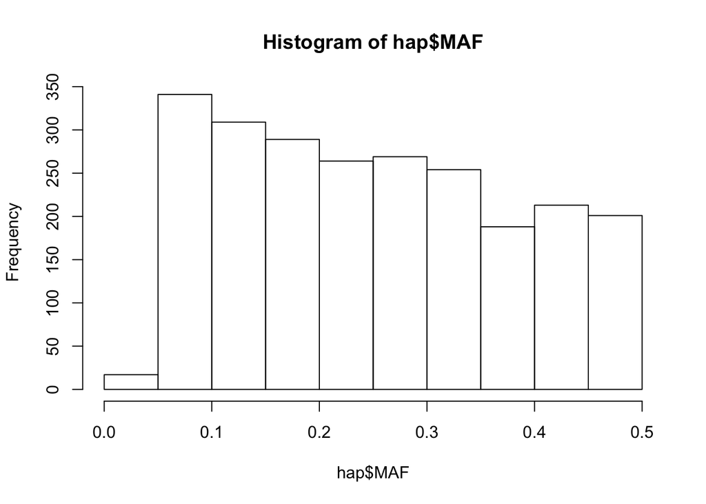

```r
#potential genotype filtering
hap <- tassel5_to_params(marker, 11, z = 2033) #get population paramters

hist(hap$MAF) #there are few alleles that could be filtered
```

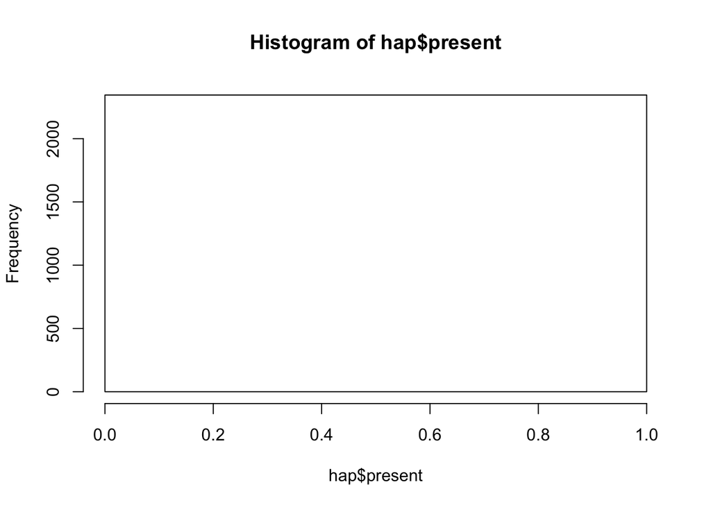

```r
hist(hap$present) #why is this?  Imputed data for all values
```

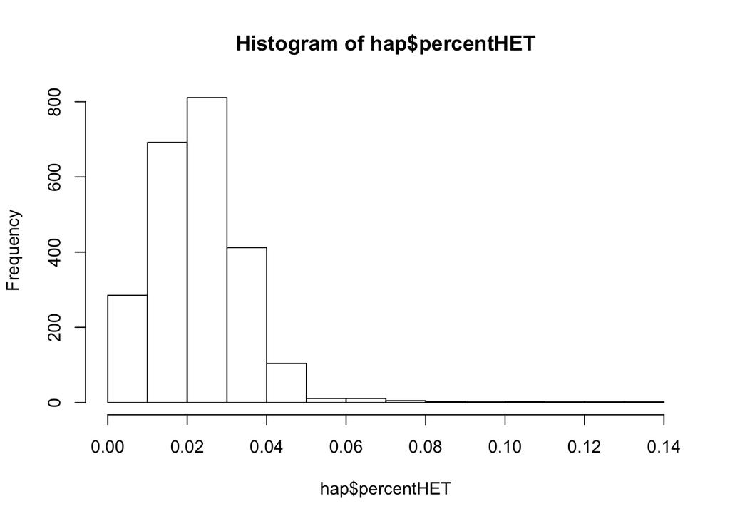

```r
hist(hap$percentHET) #inbred wheat lines is this expected?
```

```r
hap <- hap[hap$MAF > 0.05, ] #filter at MAF > 0.05

geno <- hap_to_G(hap, 17) #make marker matrix

rownames(geno) <- geno$`rs#` #give rownames
gs_marker <- t(geno[, 18:ncol(geno)])

dim(gs_marker) #check gs_marker number
```

```
## [1] 2033 2328
```

```r
#potential phenotype filtering
str(phen)
```

```
## 'data.frame':    3091 obs. of  17 variables:
##  $ GID_DNA      : chr  "GID6738288" "GID6689579" "GID6689482" "GID6689550" ...
##  $ blup_gs1     : num  -0.00987 -0.01169 0.06774 -0.04308 -0.05827 ...
##  $ blup_gs2     : num  0.0146 0.0128 0.0501 -0.0286 -0.041 ...
##  $ blup_gs3     : num  0.00598 0.02622 0.0546 -0.02407 -0.02115 ...
##  $ blup_n1      : num  -0.145 0.3079 -0.0195 0.0414 0.1364 ...
##  $ blup_n2      : num  -5.54e-08 -1.04e-07 2.65e-07 -1.02e-07 1.57e-07 ...
##  $ blup_n3      : num  -0.0281 -0.0283 -0.2842 0.2254 -0.1793 ...
##  $ Experiment_id: chr  "14_OBR_EYT" "14_OBR_EYT" "14_OBR_EYT" "14_OBR_EYT" ...
##  $ Entry        : int  103 104 105 106 107 108 109 110 111 112 ...
##  $ cimmyt_tid   : int  1 1 1 1 1 1 1 1 1 1 ...
##  $ notes        : chr  "EYTBWDRIP_01" "EYTBWDRIP_01" "EYTBWDRIP_01" "EYTBWDRIP_01" ...
##  $ gy_effect    : num  0.0389 0.048 -0.1518 0.2397 -0.1478 ...
##  $ gs           : num  0.00357 0.00913 0.05749 -0.03191 -0.04015 ...
##  $ ir           : num  -0.0577 0.0932 -0.1012 0.0889 -0.0143 ...
##  $ model        : chr  "Simple" "Simple" "Simple" "Simple" ...
##  $ blup_gs4     : num  NA NA NA NA NA NA NA NA NA NA ...
##  $ blup_n4      : num  NA NA NA NA NA NA NA NA NA NA ...
```

```r
#only get 2014 drought
phen <- phen[phen$Experiment_id == '14_OBR_EYT', ]
phen <- phen[, c(1, 8:10, 12)] #only get grain yield, trial_id, GID etc.  Just easier to work with less mess
any(is.na(phen$gy_effect)) #check that all grain yield is ther
```

```
## [1] FALSE
```

```r
#get only marker in phen
gs_marker <- gs_marker[rownames(gs_marker) %in% phen$GID_DNA, ]

nrow(gs_marker) == nrow(phen) #check number of individuals in marker and phenotype population the same
```

```
## [1] TRUE
```

# Set up Model

```r
require(rrBLUP)
gs_pred = NULL

for(i in 1:max(phen$cimmyt_tid)){ #enter for loop #MODIFIED
    x = phen
    print(paste('Loop or CV fold:', i, sep=' ')) #check progress
      phenoPredict <- x[x$cimmyt_tid == i ,] #get phenoPredict group
      phenoTrain <- x[!x$cimmyt_tid == i , ] #get phenoTrain group

     #order marker matrix by rbind values of phenoTrain and phenoPredict
      ord <- c(as.character(phenoTrain$GID_DNA), as.character(phenoPredict$GID_DNA))

      #order genotypic data
      g <- gs_marker[match(ord, rownames(gs_marker)),]

      print(paste('Check that g has training individuals first: ', all(as.character(phenoTrain$GID_DNA) == rownames(g)[1:nrow(phenoTrain)] && !is.null(phenoTrain$GID_DNA)), sep='')) #check
      print(paste('Check g has prediction individuals last: ', all(as.character(phenoPredict$GID_DNA) == rownames(g)[(nrow(g)-nrow(phenoPredict)+1):nrow(g)]  && !is.null(phenoPredict$GID_DNA)) , sep=''))

        #rrBLUP for genomic additive relationship matrix
        mat <- A.mat(g)

     ##prepare phenotype frame
       phenoPredict[ , 'gy_effect'] <- NA #set phenotype value to NA

       ##make phenotypic frame
       phenotypic <- rbind(phenoTrain, phenoPredict)

    #check that phenotypic and genotypic order are correct
       print(paste('Check that all phenotype data is in order:  ', all(rownames(g) == phenotypic$GID_DNA && !is.null(phenotypic$GID_DNA)), sep=''))

        ans <- kin.blup(phenotypic, K = mat, geno = "GID_DNA" , pheno ="gy_effect") #run rrBLUP

      preds <- ans$pred #extract prediction

      preds <- preds[names(preds) %in% phenoPredict$GID_DNA] #get only predictions
      preds <- as.data.frame(preds) #make into a dataframe
      preds$GID_DNA <- rownames(preds) #get plant_id
      rownames(preds) <- NULL #set rownames as NULL

      #set out
      gs_pred <- rbind(gs_pred, preds)

} #close for loop
```

```
## [1] "Loop or CV fold: 1"
## [1] "Check that g has training individuals first: TRUE"
## [1] "Check g has prediction individuals last: TRUE"
## [1] "Check that all phenotype data is in order:  TRUE"
## [1] "Loop or CV fold: 2"
## [1] "Check that g has training individuals first: TRUE"
## [1] "Check g has prediction individuals last: TRUE"
## [1] "Check that all phenotype data is in order:  TRUE"
## [1] "Loop or CV fold: 3"
## [1] "Check that g has training individuals first: TRUE"
## [1] "Check g has prediction individuals last: TRUE"
## [1] "Check that all phenotype data is in order:  TRUE"
## [1] "Loop or CV fold: 4"
## [1] "Check that g has training individuals first: TRUE"
## [1] "Check g has prediction individuals last: TRUE"
```

[output cut: 129 more lines]

# Validate Model

```r
#Evaluate prediction
accuracy <- merge(phen, gs_pred, by = 'GID_DNA') #merge prediction data set and original phenotyep data set

pdf(file = './data/Figures/GS_Accuracy_Plot.pdf', height = 6, width = 8)
plot(accuracy$gy_effect, accuracy$preds, xlab = 'Observed value', ylab = 'Predicted value') #quick graph
abline(lm(accuracy$preds~accuracy$gy_effect), col = 'red') #add trendline
dev.off()
```

```r
cor(accuracy$gy_effect, accuracy$preds) #correlation or accuracy
```

```
## [1] 0.4368455431
```

# Objective 2 Make your own model for a trait and experiment